# Customer type behaviours in Ford GoBike System

## by Darragh Merrick

## Investigation Overview

In this presentation, I will compare the two types of Customers in the Ford GoBike System Dateset, customers and subscribers, in the following features:

Distance travel

Trip duration

Year of birth

## Dataset Overview

Ford GoBike System Dateset is a dateset that contains trip data from the bike service for public use. Variables including, trip duration, start time and end time with date, start station and end station names, start and end coordinates, customer type, year of birth and gender.

## Amount of Customers vs Amount of Subscribers

In the dataset, there are more Subscriber than Customers users.

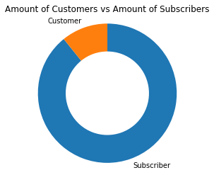

[figure not shown]

## Distance travel vs Customer type

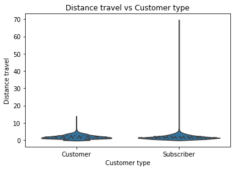

## Year of birth vs Customer type

They are no significant age difference between the groups.

note: Year of birth axis starts at 1940.

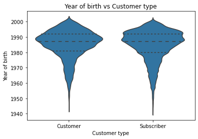

## Trip duration vs Customer type

Subscribers are more likely to take short trip duration, while customers are more likey to take long trip duration.

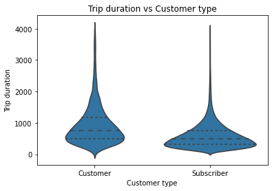

## Distance travel vs Year of birth vs Customer type

Subscribers are more likey travel from 500 to 1500m and are between 20 - 30 year old

Customers are more likey travel from 1000 to 2000m and are between 20 - 30 year old

note:

outliers where removed from this plot.

Year of birth axis starts at 1940.

only 10% of the data was used in this plot.

[figure not shown]

## Trip duration vs Year of birth vs Customer type

Subscribers are more likey travel a duration of 0 to 500s and are between 20 - 30 year old

Customers are more likey travel a duration of 500 to 1000s and are between 20 - 30 year old

note:

outliers where removed from this plot.

Year of birth axis starts at 1940.

only 10% of the data was used in this plot.

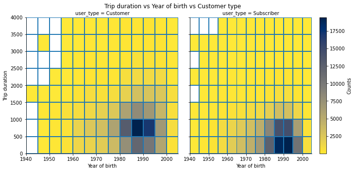

## Summary:

> Male users are the majority of users of this service.

> **User Type**
> - **subscribers are:**
> - most likely to travel from 500 to 1500m
> - most likely travel a duration of 0 to 500 seconds
> - most likely to be between 20 - 30 year old

[output not shown]